# 大数据分析与挖掘

## 07. Docker and Kubernetes

主讲人：丁平尖

## Kubernetes (K8S) 是什么

- Kubernetes 是一个开源的容器编排平台，用于自动化部署、扩展和管理容器化应用程序。
- Kubernetes 这个名字源于希腊语，意为“舵手”或“飞行员”。k8s 这个缩写是因为 k 和 s 之间有八个字符的关系。
- 它最初由 Google 开发，现在由云原生计算基金会（Cloud Native Computing Foundation, CNCF）维护。
- Kubernetes 提供了一套强大的工具和功能，使开发人员和运维人员能够更轻松地管理复杂的容器化应用程序。
- 主要功能包括：
  - **自动化部署**：Kubernetes 可以自动部署容器化应用程序，并确保它们在集群中运行。
  - **扩展和缩减**：根据需求，Kubernetes 可以自动扩展或缩减应用程序的实例数量。
  - **负载均衡**：Kubernetes 提供内置的负载均衡功能，以确保流量均匀分布到各个容器实例。
  - **自愈能力**：如果某个容器或节点出现故障，Kubernetes 会自动重新调度和恢复应用程序。
  - **服务发现和配置管理**：Kubernetes 提供服务发现机制，使容器能够相互通信，并支持配置管理以简化应用程序的配置过程。

## 什么时候需要 Kubernetes

- 当你的应用只是跑在一台机器，直接一个 docker + docker-compose 就够了，方便轻松；
- 当你的应用需要跑在 3，4 台机器上，你依旧可以每台机器单独配置运行环境 + 负载均衡器（Standalone Master）；
- 当你应用访问数不断增加，机器逐渐增加到十几台、上百台、上千台时，每次加机器、软件更新、版本回滚，都会变得非常麻烦、痛不欲生。
- Kubernetes 可以提供集中式的管理集群机器和应用，加机器、版本升级、版本回滚，那都是一个命令就搞定的事，不停机的灰度更新，确保高可用、高性能、高扩展。

## 学习前提：Docker

- 在学习 Kubernetes 之前，建议先了解 Docker 和 Linux 的基础知识。
- Docker 是什么？
  - Docker 是一种流行的容器化平台，用于创建、部署和管理容器化应用程序。Kubernetes 主要用于编排和管理 Docker 容器。
  - 你也可以把它理解为一个轻量的虚拟机，它只虚拟你软件需要的运行环境，多余的一点都不要，
  - 而普通虚拟机则是一个完整而庞大的系统，包含各种不管你要不要的软件。
- 学习文档：
  - https://docs.docker.com/manuals/
  - https://yeasy.gitbook.io/docker_practice

## 跟普通虚拟机的对比

| 特性 | 普通虚拟机 | Docker |
| --- | --- | --- |
| 跨平台 | 通常只能在桌面级系统运行，例如 Windows/Mac，无法在不带图形界面的服务器上运行 | 支持的系统非常多，各类 Windows 和 Linux 都支持 |
| 性能 | 性能损耗大，内存占用高，因为是把整个完整系统都虚拟出来了 | 性能好，只虚拟软件所需运行环境，最大化减少没用的配置 |
| 自动化 | 需要手动安装所有东西 | 一个命令就可以自动部署好所需环境 |
| 稳定性 | 稳定性不高，不同系统差异大 | 稳定性好，不同系统都一样部署方式 |

## Docker 部署的优势

- 打包：就是把你软件运行所需的依赖、第三方库、软件打包到一起，变成一个安装包
- 分发：你可以把你打包好的“安装包”上传到一个镜像仓库，其他人可以非常方便的获取和安装
- 部署：拿着“安装包”就可以一个命令运行起来你的应用，自动模拟出一模一样的运行环境，不管是在 Windows/Mac/Linux。

## Docker 通常用来做什么

- 应用分发、部署，方便传播给他人安装。特别是开源软件和提供私有部署的应用
- 快速安装测试/学习软件，用完就丢（类似小程序），不把时间浪费在安装软件上。
- 多个版本软件共存，不污染系统，例如 Python2、Python3，Redis4.0，Redis5.0
- Docker 可以用于部署大数据处理框架，如 Hadoop 和 Spark，简化集群的配置和管理。

## 重要概念：镜像、容器

- 镜像：可以理解为软件安装包，可以方便的进行传播和安装。
- 容器：软件安装后的状态，每个软件运行环境都是独立的、隔离的，称之为容器。

## 镜像加速源

- registry-mirrors: 镜像加速器列表，拉取镜像时会优先使用这些镜像源，加速下载。

[figure not shown]

## 直接安装的缺点

- 安装麻烦，可能有各种依赖，运行报错。例如：WordPress，ElasticSearch，Redis
- 可能对 Windows 并不友好，运行有各种兼容问题，软件只支持 Linux 上跑
- 不方便安装多版本软件，不能共存。
- 电脑安装了一堆软件，拖慢电脑速度。
- 不同系统和硬件，安装方式不一样

## Docker 安装的优点

- 一个命令就可以安装好，快速方便
- 有大量的镜像，可直接使用
- 没有系统兼容问题，Linux 专享软件也照样跑
- 支持软件多版本共存
- 用完就丢，不拖慢电脑速度
- 不同系统和硬件，只要安装好 Docker 其他都一样了，一个命令搞定所有

## Docker安装WordPress

WordPress 是一个流行的开源内容管理系统（CMS），可快速搭建网站和博客

[figure not shown]

## 案例： 安装 WordPress 并配置数据库

- Docker：管理单个镜像/容器（build/run/exec）。
- Docker Compose：管理多容器应用（组合、链接、统一启动/停止）。
- Example `compose.yaml` for wordpress

## compose.yaml 示例

```
# 说明：此 Compose 文件用于在本地以 Docker 容器运行 WordPress + MySQL 环境。
# 结构概览：
# - services: 定义两个服务：wordpress（Web 应用）和 db（MySQL 数据库）。
# - volumes: 使用命名卷来持久化 WordPress 文件和 MySQL 数据库数据。

services: # 定义服务集合

  wordpress: # WordPress 服务
    image: wordpress # 使用官方 wordpress 镜像（PHP + Apache）
    restart: always # 容器异常退出时自动重启
    ports: # 端口映射列表
      - 8080:80 # 将主机 8080 映射到容器 80（访问 http://localhost:8080/）
    environment: # 环境变量：数据库连接信息
      WORDPRESS_DB_HOST: db # 数据库主机（Compose 服务名）
      WORDPRESS_DB_USER: exampleuser # WordPress 数据库用户名
      WORDPRESS_DB_PASSWORD: examplepass # WordPress 数据库密码（注意生产环境不要明文）
      WORDPRESS_DB_NAME: exampledb # WordPress 使用的数据库名
    volumes: # 挂载卷：持久化网站文件
      - wordpress:/var/www/html # 将命名卷 wordpress 挂载到 /var/www/html

  db: # MySQL 数据库服务
    image: mysql:8.0 # 使用 MySQL 8.0 官方镜像
    restart: always # 容器异常退出时自动重启
    environment: # MySQL 环境变量
      MYSQL_DATABASE: exampledb # 启动时创建的数据库名，应与 WORDPRESS_DB_NAME 一致
      MYSQL_USER: exampleuser # 创建的非 root 用户
      MYSQL_PASSWORD: examplepass # 非 root 用户的密码（注意生产环境不要明文）
      MYSQL_RANDOM_ROOT_PASSWORD: '1' # 随机生成 root 密码（'1' 或 'true'）
    volumes: # 持久化数据库数据
      - db:/var/lib/mysql # 将命名卷 db 挂载到 /var/lib/mysql

volumes: # 定义命名卷
  wordpress: # WordPress 内容卷
  db: # 数据库数据卷
```

```
wordpress: # WordPress 服务
    image: wordpress # 使用官方 wordpress 镜像（PHP + Apache）
    restart: always # 容器异常退出时自动重启
    ports: # 端口映射列表
      - 8080:80 # 将主机 8080 映射到容器 80（访问 http://localhost:8080/）
    environment: # 环境变量：数据库连接信息
      WORDPRESS_DB_HOST: db # 数据库主机（Compose 服务名）
      WORDPRESS_DB_USER: exampleuser # WordPress 数据库用户名
      WORDPRESS_DB_PASSWORD: examplepass # WordPress 数据库密码（注意生产环境不要明文）
      WORDPRESS_DB_NAME: exampledb # WordPress 使用的数据库名
    volumes: # 挂载卷：持久化网站文件
      - wordpress:/var/www/html # 将命名卷 wordpress 挂载到 /var/www/html
```

```
db: # MySQL 数据库服务
    image: mysql:8.0 # 使用 MySQL 8.0 官方镜像
    restart: always # 容器异常退出时自动重启
    environment: # MySQL 环境变量
      MYSQL_DATABASE: exampledb # 启动时创建的数据库名，应与 WORDPRESS_DB_NAME 一致
      MYSQL_USER: exampleuser # 创建的非 root 用户
      MYSQL_PASSWORD: examplepass # 非 root 用户的密码（注意生产环境不要明文）
      MYSQL_RANDOM_ROOT_PASSWORD: '1' # 随机生成 root 密码（'1' 或 'true'）
    volumes: # 持久化数据库数据
      - db:/var/lib/mysql # 将命名卷 db 挂载到 /var/lib/mysql
```

## 运行WordPress

- Run docker compose up, wait for it to initialize completely,
- and visit http://localhost:8080

[figure not shown]

## 更多相关命令

- `docker ps` 查看当前运行中的容器
- `docker images` 查看镜像列表
- `docker rm container-id` 删除指定 id 的容器
- `docker stop/start container-id` 停止/启动指定 id 的容器
- `docker rmi image-id` 删除指定 id 的镜像
- `docker volume ls` 查看 volume 列表
- `docker network ls` 查看网络列表

## Kubernetes 基本概念

- 节点（Node）：一个节点是一个运行 Kubernetes 中的主机。
- 容器组（Pod）：一个 Pod 对应于由若干容器组成的一个容器组，同个组内的容器共享一个存储卷(volume)。
- web 界面（ux）：用户可以通过 web 界面操作 Kubernetes。
- 命令行操作（cli）：kubectl命令。

## minikube

- Minikube 是一个工具，可以在本地计算机上快速运行一个单节点的 Kubernetes 集群，适合学习和测试 Kubernetes。
- 安装文档：https://minikube.sigs.k8s.io/docs/start/?arch=%2Fwindows%2Fx86-64%2Fstable%2F.exe+download

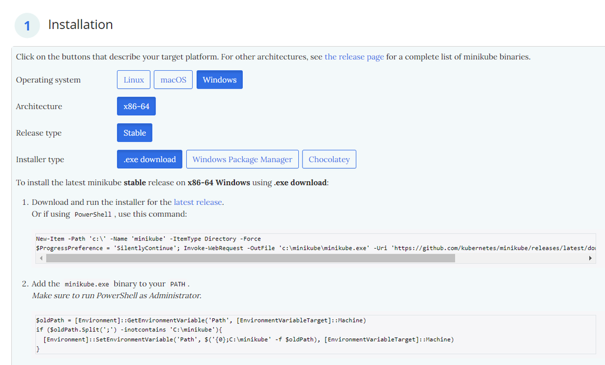

## minikube操作

- 启动集群

```
minikube start
```

```python
!kubectl get nodes
```

```
NAME           STATUS     ROLES           AGE    VERSION
minikube       Ready      control-plane   133m   v1.34.0
minikube-m02   NotReady   <none>          17m    v1.34.0
```

```python
!minikube node add --worker
```

```
* 将节点 m03 作为 [worker] 添加到集群 minikube
* 在集群中 "minikube" 启动节点 "minikube-m03" worker
* 正在拉取基础镜像 v0.0.48 ...
* 正在验证 Kubernetes 组件...
* 已成功将 m03 添加到 minikube！
```

[output not shown]

```python
!kubectl get nodes
```

```
NAME           STATUS   ROLES           AGE     VERSION
minikube       Ready    control-plane   3h22m   v1.34.0
minikube-m02   Ready    <none>          87m     v1.34.0
minikube-m03   Ready    <none>          34s     v1.34.0
```

```python
!minikube node delete minikube-m03
!kubectl get nodes
```

```
* 正在从集群 minikube 中删除节点 minikube-m03
* 正在停止节点 "minikube-m03" ...
* 正在通过 SSH 关闭“minikube-m03”…
* 正在删除 docker 中的“minikube-m03”…
* 节点 minikube-m03 已成功删除。
NAME           STATUS   ROLES           AGE     VERSION
minikube       Ready    control-plane   3h23m   v1.34.0
minikube-m02   Ready    <none>          87m     v1.34.0
```

```python
!minikube stop
```

```
* 正在停止节点 "minikube-m02" ...
* 正在通过 SSH 关闭“minikube-m02”…
* 正在停止节点 "minikube" ...
* 正在通过 SSH 关闭“minikube”…
* 2 个节点已停止。
```

## minikube部署应用程序

- 创建示例部署并将其公开在端口 8080 上：

```
# 创建名为 hello-minikube 的部署，使用 kicbase/echo-server:1.0 镜像
kubectl create deployment hello-minikube --image=kicbase/echo-server:1.0
# 将部署暴露为 NodePort 服务，端口为 8080
kubectl expose deployment hello-minikube --type=NodePort --port=8080
```

- 这可能需要一点时间，但当您运行以下命令时，您的部署将很快显示出来：
- 访问此服务的最简单方法是让 minikube 为您启动 Web 浏览器：

```
# 查看 hello-minikube 服务的详细信息，包括分配的端口
kubectl get services hello-minikube
# 自动在浏览器打开服务页面，方便访问和测试
minikube service hello-minikube
```

- 或者，使用 kubectl 转发端口：

```
kubectl port-forward service/hello-minikube 7080:8080
```

## minikube部署应用程序

[figure not shown]

## Kubernetes 扩展

[figure not shown]

## 腾讯云容器服务TKE（Tencent Kubernetes Engine）

- 腾讯云容器服务 TKE（Tencent Kubernetes Engine）是腾讯云提供的托管式 Kubernetes 服务，旨在简化容器化应用的部署和管理。

https://cloud.tencent.com/product/tke

## 腾讯云容器服务TKE（Tencent Kubernetes Engine）

[figure not shown]

## 裸机安装Kubernetes集群

[figure not shown]

## 裸机安装Kubernetes集群

[figure not shown]

## 租用腾讯云服务器CVM（Cloud Virtual Machine）

[figure not shown]

## 租用腾讯云服务器CVM（Cloud Virtual Machine）

[figure not shown]

## 远程连接云服务器

[figure not shown]

## 远程连接云服务器

[figure not shown]

## 组件

- 主节点需要组件
  - 容器运行时（如docker） 负责运行容器的软件
  - kubectl 集群命令行交互工具
  - kubeadm 集群初始化工具
- 工作节点需要组件 (https://kubernetes.io/zh-cn/docs/concepts/overview/components/#node-components)
  - 容器运行时（如docker） 负责运行容器的软件
  - kubelet 管理 Pod 和容器，确保他们健康稳定运行。
  - kube-proxy 网络代理，负责网络相关的工作

## 开始安装

- 脚本搭建： https://github.com/lework/kainstall
- 手动搭建
1. 每个节点分别设置对应主机名

```
hostnamectl set-hostname master
hostnamectl set-hostname node1
hostnamectl set-hostname node2
```

2. 所有节点都修改 hosts

```
vim /etc/hosts
# 修改 hosts 文件，添加以下内容
172.19.0.14 node1
172.19.0.4 node2
172.19.0.17 master
```

3. 所有节点关闭 SELinux

```
# SELinux 常见于 RHEL/CentOS/Fedora 等发行版；对安全很有帮助，但会导致服务访问被拒
# 关闭 SELinux
setenforce 0
# 修改 SELinux 配置文件，将其设置为禁用
sed -i --follow-symlinks 's/SELINUX=enforcing/SELINUX=disabled/g' /etc/sysconfig/selinux
```

4. 所有节点防火墙关闭

```
systemctl stop firewalld   # 停止防火墙服务
systemctl disable firewalld   # 禁用防火墙服务，开机不自启
```

5. 配置 Kubernetes YUM 源（阿里云镜像）

以下命令将阿里云的 Kubernetes YUM 源配置到 CentOS 7 系统，便于后续安装 Kubernetes 相关组件。

```
# 创建 Kubernetes YUM 源配置文件（使用阿里云镜像）
cat <<EOF > kubernetes.repo   # 创建一个新的 Kubernetes YUM 源配置文件
[kubernetes]                  # 仓库名称
name=Kubernetes               # 仓库描述
baseurl=https://mirrors.aliyun.com/kubernetes/yum/repos/kubernetes-el7-x86_64  # 阿里云镜像源地址
enabled=1                     # 启用该仓库
gpgcheck=0                    # 关闭 GPG 校验
repo_gpgcheck=0               # 关闭仓库 GPG 校验
gpgkey=https://mirrors.aliyun.com/kubernetes/yum/doc/yum-key.gpg https://mirrors.aliyun.com/kubernetes/yum/doc/rpm-package-key.gpg  # GPG 公钥地址（可选）
EOF
mv kubernetes.repo /etc/yum.repos.d/   # 移动配置文件到 yum 源目录

# 添加 Docker YUM 源（阿里云镜像）以便安装 Docker
yum-config-manager --add-repo http://mirrors.aliyun.com/docker-ce/linux/centos/docker-ce.repo
```

```
cat <<EOF > kubernetes.repo
[kubernetes]
name=Kubernetes
baseurl=https://mirrors.aliyun.com/kubernetes/yum/repos/kubernetes-el7-x86_64
enabled=1
gpgcheck=0
repo_gpgcheck=0
gpgkey=https://mirrors.aliyun.com/kubernetes/yum/doc/yum-key.gpg https://mirrors.aliyun.com/kubernetes/yum/doc/rpm-package-key.gpg
EOF
mv kubernetes.repo /etc/yum.repos.d/

yum-config-manager --add-repo http://mirrors.aliyun.com/docker-ce/linux/centos/docker-ce.repo
```

6. 为所有节点安装组件

```
# 安装 kubelet、kubectl、kubeadm 和 Docker 组件（指定版本）
yum install -y kubelet-1.22.4 kubectl-1.22.4 kubeadm-1.22.4 docker-ce
```

7. 启动 kubelet、docker，并设置开机启动（所有节点）

```
systemctl enable kubelet        # 设置 kubelet 服务开机自启，保证节点重启后自动启动
systemctl start kubelet         # 启动 kubelet 服务，负责管理 Kubernetes 节点上的 Pod 和容器
systemctl enable docker         # 设置 Docker 服务开机自启，保证节点重启后自动启动
systemctl start docker          # 启动 Docker 服务，提供容器运行环境
```

8. 修改 docker 配置（所有节点）

```
# kubernetes 官方推荐 docker 等使用 systemd 作为 cgroupdriver，否则 kubelet 启动不了

cat <<EOF > daemon.json
{
  "exec-opts": ["native.cgroupdriver=systemd"],  # 设置 cgroupdriver 为 systemd，Kubernetes 推荐
  "registry-mirrors": ["https://ud6340vz.mirror.aliyuncs.com"]  # 配置 Docker 镜像加速器，提高拉取速度
}
EOF
mv daemon.json /etc/docker/  # 将配置文件移动到 Docker 配置目录

# 重启生效
systemctl daemon-reload    # 重新加载 systemd 管理的所有服务配置，确保新配置生效
systemctl restart docker   # 重启 Docker 服务，使配置更改立即生效
```

```
cat <<EOF > daemon.json
{
  "exec-opts": ["native.cgroupdriver=systemd"],
  "registry-mirrors": ["https://ud6340vz.mirror.aliyuncs.com"]
}
EOF
mv daemon.json /etc/docker/

systemctl daemon-reload
systemctl restart docker
```

9. 用 kubeadm 初始化集群（仅在主节点跑）

```
# 初始化集群控制台 Control plane
# 失败了可以用 kubeadm reset 重置

# 初始化 Kubernetes 控制平面（仅主节点执行），指定镜像仓库为阿里云镜像，加速拉取所需镜像
kubeadm init --image-repository=registry.aliyuncs.com/google_containers
# 记得把 kubeadm join xxx 保存起来
# 忘记了重新获取：kubeadm token create --print-join-command

# 复制授权文件，以便 kubectl 可以有权限访问集群
# 如果你其他节点需要访问集群，需要从主节点复制这个文件过去其他节点

# 创建 .kube 目录（如果不存在），用于存放 kubeconfig 配置文件
mkdir -p $HOME/.kube
# 复制 Kubernetes 管理员配置文件到当前用户的 .kube 目录
cp -i /etc/kubernetes/admin.conf $HOME/.kube/config
# 修改配置文件的所有者为当前用户，确保 kubectl 有权限访问
chown $(id -u):$(id -g) $HOME/.kube/config
```

10. 把工作节点加入集群（只在工作节点跑）

```
# 用 kubeadm join 命令将工作节点加入 Kubernetes 集群，需替换为实际的 join 命令
kubeadm join 172.19.0.17:6443 --token m8usq6.6dou8eqq1g2f7zrd  --discovery-token-ca-cert-hash sha256:41e144f9a7cfeacf64eeace0ec7318d6768755a586cdd011ccd9a8ac7c84ced4
```

11. 安装网络插件，否则 node 是 NotReady 状态（主节点跑）

```
# 为 Kubernetes 集群安装 Flannel 网络插件，确保各节点网络互通。
kubectl apply -f https://raw.githubusercontent.com/coreos/flannel/master/Documentation/kube-flannel.yml
```

12. 查看节点状态

```
# 查看节点状态
kubectl get nodes
```